# Black-Scholes

## Benjino Chery

benjinochery95@gmail.com

January 2023

## Pricing European Options

One of the best ways to value is to use the Black-Scholes model. The Black-Scholes model takes five inputs and makes few assumptions that can lead to errors.

#### Black-Scholes inputs

To use that model to calculate the price of the European Option we need to know the following variables:

1. the strike price of an option (X)
2. the current price of the underlying asset (s0)
3. the time to expiration (T)
4. the risk-free interest rate (r)
5. the volatility of the underlying asset which can be derived from the market(vol)

#### Black-Scholes assumptions

- The option is European
- The underlying asset pays no dividends during the life of the option
- Market movements is unpredictable
- The risk-free interest rate and the asset's volatility remain the same during the life of the option
- No transaction cost is paid to buy the option

#### Example

Suppose we want to price a European option with the following characteristics: strike = 240, expiration T = 1/12 current stock price = 242, volatility = 0.5, interest rate = 0.03

```python
%run option_module.ipynb
%run variable_module.ipynb
```

```python
o_type = 'call'
strike = 240
cur_price = 242
interest_rate = 3
volatility = 0.5
duration = 1/12

call_1 = option(o_type,strike, cur_price,interest_rate,volatility,duration)
print('Call:',round(call_1.price(),4))

put_1 = option('put',240, 242,3,0.5,1/12)
print('Put:',round(put_1.price(),4))
```

```
Call: 15.1864
Put: 12.5871
```

#### Strike Price

The price of an option is related to its strike price. While call option price is a decreasing function of strike, put price is an increasing function of strike. An option is more expensive when its probability of being in the money at expiration is high. Therefore, an option with a strike price that is close to the spot price will be more expensive than one that is deeply out of the money.

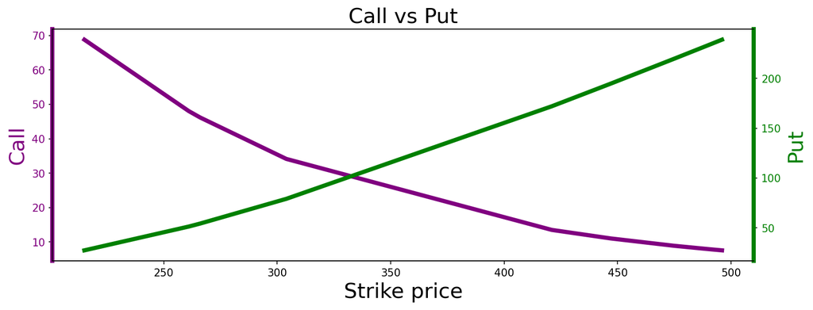

```python
list_ca =[]
list_x = []
list_pu = []
for i in range(10):
    strike = random.randrange(200,500)
    ca = option('call',strike,250,3,0.5,1)
    list_ca.append(round(ca.price(),2))
    pu = option('put',strike,250,3,0.5,1)
    list_pu.append(round(pu.price(),2))
    list_x.append(strike)

plot_strikes(list_x,list_ca,list_pu)
```

#### Spot Price

The price of an option is also influenced by the current price of the stock. Call option price is an increasing function of the spot price but put price is a decreasing function of the spot price.

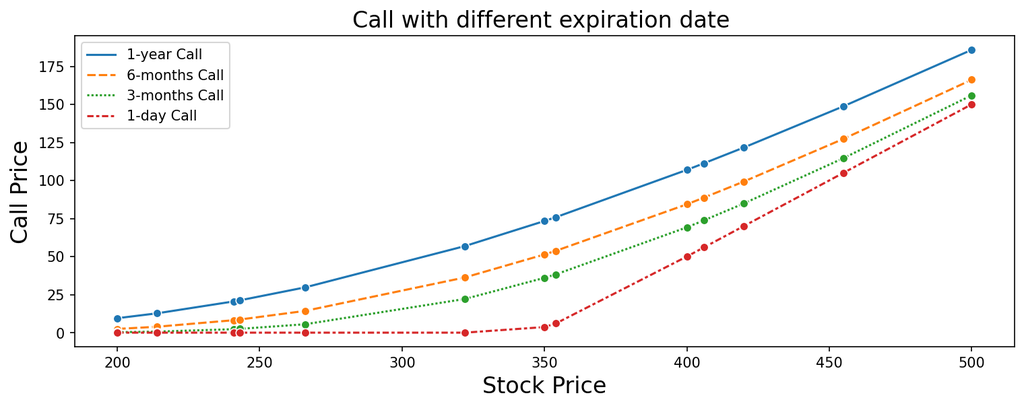

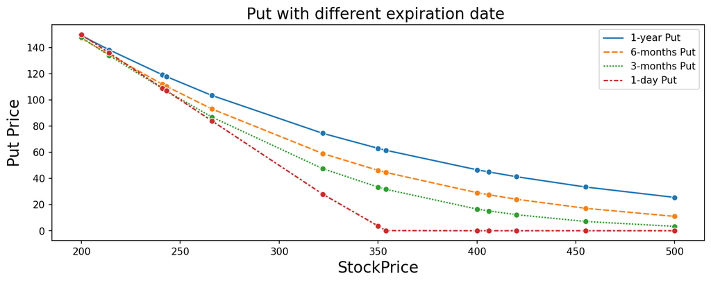

```python
p_price(200,500)
```

#### Implied volatility

It represents a measure of the potential fluctuations in the future price of a stock's return.. The more volatile a stock, the higher the option price.

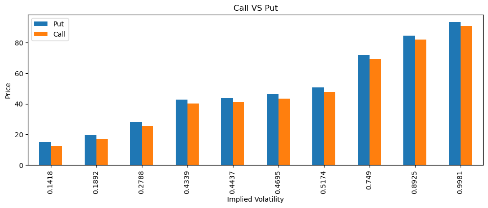

```python
fvolatility()
```

#### Duration

Put and call price can be thought as a decreasing function of time. As we approach the expiration date there is less uncertainty. Hence the option become less valuable.

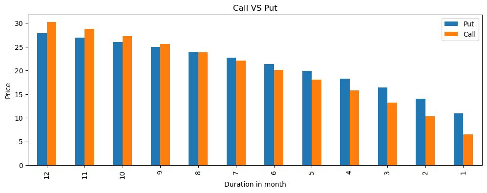

```python
fduration()
```

## Risk Management

The Writer of an option is exposed to risk.

1. When you long or short an option you might want to know the probability that the option would be in the money at expiration or the probability that the stock price will be greater or less than a specific value.
2. You can also calculate the probability that your losses are less than a specific amount.

```python
confi = 90
drift = 0.05
print('Prob that call_1 is in the money is', round(call_1.inTheMoney(drift),4))

print(f"The Value at risk with confidence level {confi/100} is",put_1.value_at_risk(confi,drift))
```

```
Prob that call_1 is in the money is 0.5344
The Value at risk with confidence level 0.9 is 12.6186
```

### Delta-Hedging

Delta hedging is a trading strategy used by market maker to protect the value of their portfolio from small price changes of the underlying asset.

Suppose you have sold a European call with strike 240, expiration T = 1/12 on a stock that is trading at 242, with volatility = 0.5, with r = 0.03. How many shares of stock should you purchase to achieve delta-neutrality

```python
ex = option('call',240,242,3,0.5,1/12)
print(ex.delta_hedging(1))
```

```
The portfolio should have 0.5584 shares, -119.9532 in the money market, and -1 call.
```

### Delta-Gamma Hedging

Delta-Gamma Hedging is a trading strategy used to reduce the risk created when the stock price makes strong up or down moves.

Suppose the risk-free rate is 0.03 and a stock whose volatility is 0.2 is trading at $10 and the following options are available:

1. a European call with strike 15, expiration at T = 1
2. a European call with strike 20, expiration at T = 1

You have sold one strike-20 European call. How can you design a portfolio to hedge this sale with delta and gamma equal to 0?

```python
volatility1 = 0.2
cur_price1 = 10
interest_rate1 = 3

call_15 = option('call',15, cur_price1, interest_rate1, volatility1, 1)
call_20 = option('call',20, cur_price1, interest_rate1, volatility1, 1)

print(call_20.delta_gamma_hedging(1,call_15))
```

```
The portfolio should have -0.0004 shares, long 0.0276 of the option with strike 15.0
```

### Hedging Strategy

The value of an option depends not only on the price of the underlying asset but also on its duration, the current interest rate, and the volatility of the underlying asset. Hence, one might want to protect their portfolio against other shock besides changes affecting the price of the asset.  
The Greek parameters (**Gamma, Theta, Vega, Rho**) can be used to mitigate the risk of small changes of a particular variable that affect the value of the portfolio. For instance, If you were concerned about sudden turns in stock price and in interest rate you can build delta-rho neutral portfolio.

```python
put_2 = option('put',55,50,3,0.4,0.5)
#put_22 = option('call',15,10,3,0.2,1)
print(round(put_2.vega(),4))
print(round(put_2.gamma(),4))
```

```
13.9622
0.0279
```

#### Sources

- Mathematics for Finance (Capinski, Zastawniak, 2nd edition)
- Lecture notes (E. Fink)
- https://www.investopedia.com/